# Part II - Prosper Loan Data Exploration

## by Adaobi Muoemenam

## Investigation Overview

My investigation is aimed at these points:

- Popular loans (amount and categories)
- How investors choose to finance loans
- Accuracy of borrower profiling

## Dataset Overview

The dataset has information on 113937 loans (rows) which are represented by 81 variables (columns) for each loan. To answer the questions above, I had to focus on some variables in the dataset which are:  
'LoanKey', 'Term','ClosedDate', 'EmploymentStatus', 'Occupation', 'Recommendations', 'LoanStatus', 'BorrowerRate', 'ProsperRating (numeric)', 'StatedMonthlyIncome', 'TotalProsperLoans', 'LoanOriginalAmount', 'ListingCategory (numeric)', 'LoanOriginationDate','DelinquenciesLast7Years', 'Investors'

## Distribution of Loan Amounts

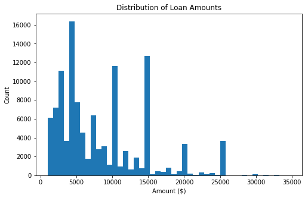

## Popularity of Loan Categories

This is the category of the listing that the borrower selected when posting their listing: 0 - Not Available, 1 - Debt Consolidation, 2 - Home Improvement, 3 - Business, 4 - Personal Loan, 5 - Student Use, 6 - Auto, 7- Other, 8 - Baby&Adoption, 9 - Boat, 10 - Cosmetic Procedure, 11 - Engagement Ring, 12 - Green Loans, 13 - Household Expenses, 14 - Large Purchases, 15 - Medical/Dental, 16 - Motorcycle, 17 - RV, 18 - Taxes, 19 - Vacation, 20 - Wedding Loans

Debt consolidation is clearly the highest type of loan taken. It accounts for more than all the other loans combined in frequency. This makes sense as people take a debt consolidation to mop up all their existing loans with more favorable payment plans and periods.

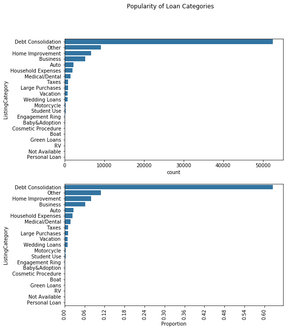

## Loan Amount vs. Investors

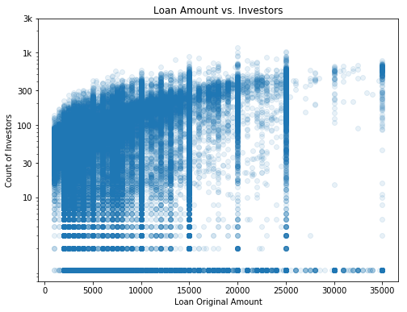

## Listing category vs. Loan status

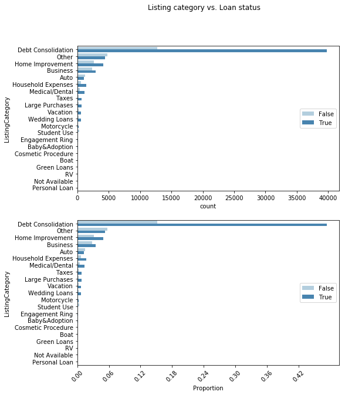

## Loan Amount by Loan Status and Ratings

The hierarchy in rating by loan amount is clear when clustered across loan status values. The pattern looks quite systematic.  
Borrowers with the highest rating (7) still default on their loans. Although good ratings give access to better loans, caution is advised for investors who consider this as a basis in the decision making process on the safety of the returns on investments.

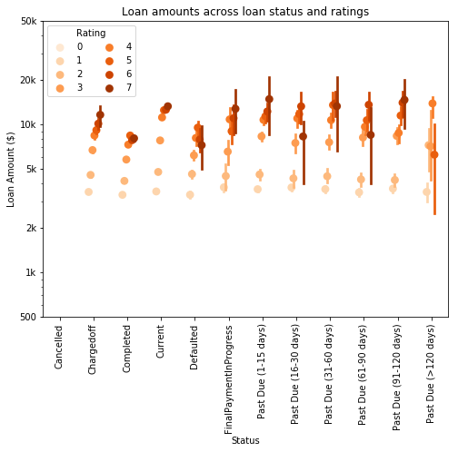